**20CS001_Parth Adesara**

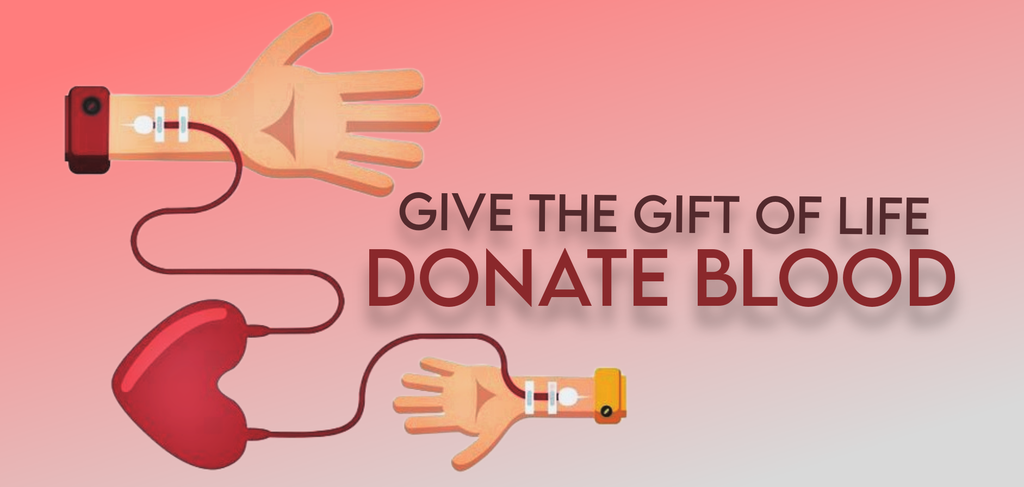

# Predict Blood Donation for Future Expectancy

### Introduction

Blood transfusion saves lives - from replacing lost blood during major surgery or a serious injury to treating various illnesses and blood disorders. Ensuring that there's enough blood in supply whenever needed is a serious challenge for the health professionals. Till day, donated blood remains a critical resource during emergencies.

Our dataset is collected from the donor database of Blood Transfusion Service Center in Hsin-Chu City in Taiwan. The center passes its blood transfusion service bus to one university in Hsin-Chu City to gather blood donated about every three months. The dataset, obtained from the UCI Machine Learning Repository, consists of a random sample of 748 donors.

The data is stored in `transfusion.data` and it is structured according to RFMTC marketing model (a variation of RFM). We'll explore what that means in this notebook.

### Problem Statement

We want to predict whether or not a donor will give blood the next time or not. Full model-building process: from inspecting the dataset to using the tpot library to automate your Machine Learning pipeline.

### Project Tasks

[figure not shown]

## Loading the blood donations data

```python
# Filtering out the warnings
import warnings

warnings.filterwarnings('ignore')
```

```python
# Importing the required libraries

import numpy as np
import pandas as pd

from sklearn.model_selection import train_test_split
from tpot import TPOTClassifier
from sklearn.metrics import confusion_matrix,accuracy_score,roc_auc_score

import seaborn as sns
import matplotlib.pyplot as plt
%matplotlib inline
```

```python
filepath = "C:\\Users\\parth\\Downloads\\Data_Analytics_IBM\\Project\\transfusion.data"
# above .data file is comma delimited

df = pd.read_csv(filepath, delimiter=",")
df.head()
```

|  | Recency (months) | Frequency (times) | Monetary (c.c. blood) | Time (months) | whether he/she donated blood in March 2007 |
| --- | --- | --- | --- | --- | --- |
| 0 | 2 | 50 | 12500 | 98 | 1 |
| 1 | 0 | 13 | 3250 | 28 | 1 |
| 2 | 1 | 16 | 4000 | 35 | 1 |
| 3 | 2 | 20 | 5000 | 45 | 1 |
| 4 | 1 | 24 | 6000 | 77 | 0 |

## Inspecting transfusion DataFrame

Let's briefly return to our discussion of RFM model. RFM stands for Recency, Frequency and Monetary Value and it is commonly used in marketing for identifying your best customers. In our case, our customers are blood donors.

###### RFMTC is a variation of the RFM model. Below is a description of what each column means in our dataset:

- R (Recency - months since the last donation)
- F (Frequency - total number of donation)
- M (Monetary - total blood donated in c.c.)
- T (Time - months since the first donation)

a binary variable representing whether he/she donated blood in March 2007 (1 stands for donating blood; 0 stands for not donating blood)

It looks like every column in our DataFrame has the numeric type, which is exactly what we want when building a machine learning model. Let's verify our hypothesis.

```python
# concise summary of transfusion DataFrame
df.info()
```

```
<class 'pandas.core.frame.DataFrame'>
RangeIndex: 748 entries, 0 to 747
Data columns (total 5 columns):
 #   Column                                      Non-Null Count  Dtype
---  ------                                      --------------  -----
 0   Recency (months)                            748 non-null    int64
 1   Frequency (times)                           748 non-null    int64
 2   Monetary (c.c. blood)                       748 non-null    int64
 3   Time (months)                               748 non-null    int64
 4   whether he/she donated blood in March 2007  748 non-null    int64
dtypes: int64(5)
memory usage: 29.3 KB
```

```python
# checking for null values
df.isnull()
```

|  | Recency (months) | Frequency (times) | Monetary (c.c. blood) | Time (months) | whether he/she donated blood in March 2007 |
| --- | --- | --- | --- | --- | --- |
| 0 | False | False | False | False | False |
| 1 | False | False | False | False | False |
| 2 | False | False | False | False | False |
| 3 | False | False | False | False | False |
| 4 | False | False | False | False | False |
| ... | ... | ... | ... | ... | ... |
| 743 | False | False | False | False | False |
| 744 | False | False | False | False | False |
| 745 | False | False | False | False | False |
| 746 | False | False | False | False | False |
| 747 | False | False | False | False | False |

748 rows × 5 columns

```python
print("Rows : ", df.shape[0],"\n")
print("Columns : ", df.shape[1])
```

```
Rows :  748

Columns :  5
```

```python
df.describe()
```

|  | Recency (months) | Frequency (times) | Monetary (c.c. blood) | Time (months) | whether he/she donated blood in March 2007 |
| --- | --- | --- | --- | --- | --- |
| count | 748.000000 | 748.000000 | 748.000000 | 748.000000 | 748.000000 |
| mean | 9.506684 | 5.514706 | 1378.676471 | 34.282086 | 0.237968 |
| std | 8.095396 | 5.839307 | 1459.826781 | 24.376714 | 0.426124 |
| min | 0.000000 | 1.000000 | 250.000000 | 2.000000 | 0.000000 |
| 25% | 2.750000 | 2.000000 | 500.000000 | 16.000000 | 0.000000 |
| 50% | 7.000000 | 4.000000 | 1000.000000 | 28.000000 | 0.000000 |
| 75% | 14.000000 | 7.000000 | 1750.000000 | 50.000000 | 0.000000 |
| max | 74.000000 | 50.000000 | 12500.000000 | 98.000000 | 1.000000 |

## Creating target column

```python
# Rename columns 'whether he/she donated blood in March 2007
# as'target' column

df.rename(columns={'whether he/she donated blood in March 2007': 'target'},inplace=True)

df.head()
```

|  | Recency (months) | Frequency (times) | Monetary (c.c. blood) | Time (months) | target |
| --- | --- | --- | --- | --- | --- |
| 0 | 2 | 50 | 12500 | 98 | 1 |
| 1 | 0 | 13 | 3250 | 28 | 1 |
| 2 | 1 | 16 | 4000 | 35 | 1 |
| 3 | 2 | 20 | 5000 | 45 | 1 |
| 4 | 1 | 24 | 6000 | 77 | 0 |

## Check for Data Imbalance

We want to predict whether or not the same donor will give blood the next time the vehicle comes to campus. The model for this is a binary classifier, meaning that there are only 2 possible outcomes:

- `0` - the donor will not give blood
- `1` - the donor will give blood

Target incidence is defined as the number of cases of each individual target value in a dataset. That is, how many 0s in the target column compared to how many 1s? Target incidence gives us an idea of how balanced (or imbalanced) is our dataset.

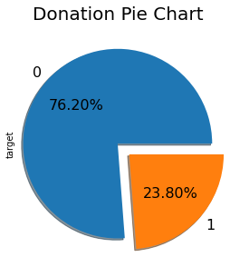

```
0    570
1    178
Name: target, dtype: int64
```

```python
explode = [0,0.2] # To slice the perticuler section
textprops = {"fontsize":16} # Font size of text in pie chart

plt.title("Donation Pie Chart\n",{"fontsize":20})
df.target.value_counts(normalize = True).plot.pie(autopct = "%0.2f%%",explode = explode,textprops=textprops, shadow = True,radius = 1.2)
plt.show() # To show pie chart only

df.target.value_counts()
```

Observations :

- The number of negative responses is much higher than the number of positive responses.
- Imbalance Dataset

### Data Exploration

```python
res = df[["Recency (months)","Frequency (times)","Monetary (c.c. blood)","Time (months)","target"]].corr(method = 'pearson')
```

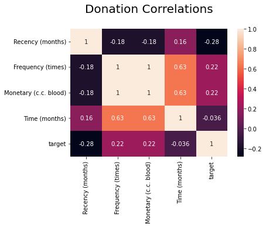

```python
plt.title("Donation Correlations\n",{"fontsize":20})
sns.heatmap(res, annot=True)
plt.show()
```

Observations :

- Positive Correlation
  - Increase in one feature will increase other feature.
- Negative Correlation
  - Increase in one feature will decrease the other feature
- We focus on which features have strong positive or negative correlation with Target Column

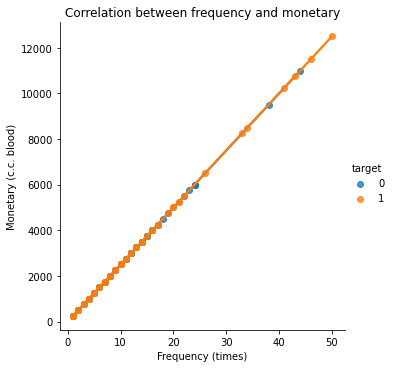

```python
sns.lmplot(data=df,x='Frequency (times)',y='Monetary (c.c. blood)',hue='target')
plt.title("Correlation between frequency and monetary")

plt.show()
```

**Frequency and monetary values are highly correlated.**

#### Handling Outliers

```python
df["Recency (months)"].describe()
```

```
count    748.000000
mean       9.506684
std        8.095396
min        0.000000
25%        2.750000
50%        7.000000
75%       14.000000
max       74.000000
Name: Recency (months), dtype: float64
```

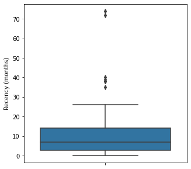

```python
# checking outlier for 'Months Since Last Donation'
plt.figure(figsize=[5,5])
sns.boxplot(data=df,y="Recency (months)")
plt.show()
```

```python
df["Recency (months)"].quantile([0.5,0.7,0.9,0.95,0.99])
```

```
0.50     7.00
0.70    14.00
0.90    21.00
0.95    23.00
0.99    25.53
Name: Recency (months), dtype: float64
```

```python
    # Boxplot is showing the outliers for recency, there are few entries having very large Recency than others.
    # Considering this entries will mislead the further analysis.

    # Excluding values outside 99 percentile for Recency

df = df[df['Recency (months)'] < np.nanpercentile(df['Recency (months)'], 99)]
```

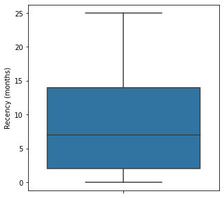

```python
# checking outlier for 'Months Since Last Donation'
plt.figure(figsize=[5,5])
sns.boxplot(data=df,y="Recency (months)")
plt.show()
```

**Months since Last Donation** - happened between 5th and 10th month

```python
df["Frequency (times)"].describe()
```

```
count    740.000000
mean       5.555405
std        5.855815
min        1.000000
25%        2.000000
50%        4.000000
75%        7.000000
max       50.000000
Name: Frequency (times), dtype: float64
```

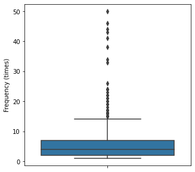

```python
# checking outlier for 'total number of donation'
plt.figure(figsize=[5,5])
sns.boxplot(data=df,y="Frequency (times)")
plt.show()
```

```python
df["Frequency (times)"].quantile([0.5,0.7,0.9,0.95,0.99])
```

```
0.50     4.00
0.70     6.00
0.90    12.00
0.95    16.00
0.99    30.27
Name: Frequency (times), dtype: float64
```

```python
# Boxplot is showing the outliers for frequency, there are few entries having very large Frequency than others.
# Considering this entries will mislead the further analysis.

# Excluding values outside 99 percentile for Frequency

df = df[df['Frequency (times)'] < np.nanpercentile(df['Frequency (times)'], 99)]
```

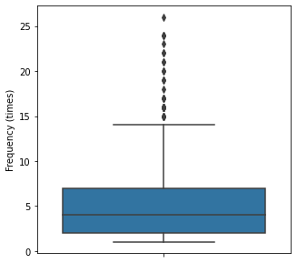

```python
# checking outlier for 'total number of donation'
plt.figure(figsize=[5,5])
sns.boxplot(data=df,y="Frequency (times)")
plt.show()
```

**Total Number of Donations** - approx. 5 times

## Splitting dataframe into train and test datasets

We'll now use `train_test_split()` method to split transfusion DataFrame.

Target incidence informed us that in our dataset `0`s appear 76% of the time. We want to keep the same structure in train and test datasets, i.e., both datasets must have 0 target incidence of 76%. This is very easy to do using the `train_test_split()` method from the `scikit` learn library - all we need to do is specify the stratify parameter. In our case, we'll `stratify` on the `target` column.

```python
X_Data = df.drop(columns='target')
X_Data.head(2)
```

|  | Recency (months) | Frequency (times) | Monetary (c.c. blood) | Time (months) |
| --- | --- | --- | --- | --- |
| 1 | 0 | 13 | 3250 | 28 |
| 2 | 1 | 16 | 4000 | 35 |

```python
Y_Data = df.target
Y_Data.head(2)
```

```
1    1
2    1
Name: target, dtype: int64
```

```python
# Split df DataFrame into
# X_train, X_test, y_train and y_test datasets,
# stratifying on the 'target' column
# As We want to keep the same structure in train and test datasets, i.e., both datasets must have 0 target incidence of 76%

X_train, X_test, y_train, y_test = train_test_split(X_Data,Y_Data,test_size=0.3,random_state=0,stratify=df.target)
```

```python
X_train.head()
```

|  | Recency (months) | Frequency (times) | Monetary (c.c. blood) | Time (months) |
| --- | --- | --- | --- | --- |
| 729 | 23 | 3 | 750 | 39 |
| 584 | 2 | 1 | 250 | 2 |
| 369 | 16 | 5 | 1250 | 40 |
| 461 | 21 | 1 | 250 | 21 |
| 258 | 4 | 3 | 750 | 28 |

## Selecting model using TPOT

TPOT is a Python Automated Machine Learning tool that optimizes machine learning pipelines using genetic programming.

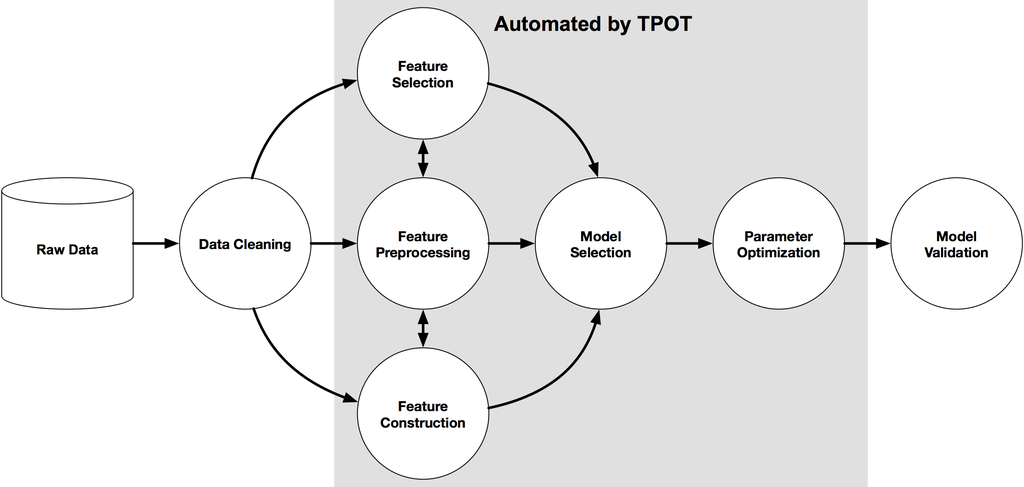

TPOT will automatically explore hundreds of possible pipelines to find the best one for our dataset. Note, the outcome of this search will be a scikit-learn pipeline, meaning it will include any pre-processing steps as well as the model.

We are using TPOT to help us zero in on one model that we can then explore and optimize further.

```python
!pip install tpot
```

```python
# Import TPOTClassifier and roc_auc_score
from tpot import TPOTClassifier
from sklearn.metrics import roc_auc_score

# Instantiate TPOTClassifier
tpot = TPOTClassifier(
    generations=5, #number of iterations to run ; pipeline optimisation process ; by default value is 100
    population_size=20, #number of individuals to retrain in the genetic programing popluation in every generation, by default value is 100
    verbosity=2, #it will state how much info TPOT will communicate while it is running
    scoring='roc_auc', #use to evaluate the quality of given pipeline
    random_state=42,
    disable_update_check=True,
    config_dict='TPOT light'
)
tpot.fit(X_train, y_train)

# AUC score for tpot model
tpot_auc_score = roc_auc_score(y_test, tpot.predict_proba(X_test)[:, 1])
print(f'\nAUC score: {tpot_auc_score:.4f}')

# Print best pipeline steps
print('\nBest pipeline steps:', end='\n')
for idx, (name, transform) in enumerate(tpot.fitted_pipeline_.steps, start=1):
    # Print idx and transform
    print(f'{idx}. {transform}')
```

```
Generation 1 - Current best internal CV score: 0.7501994752785892

Generation 2 - Current best internal CV score: 0.7501994752785892

Generation 3 - Current best internal CV score: 0.754972005842259

Generation 4 - Current best internal CV score: 0.754972005842259

Generation 5 - Current best internal CV score: 0.754972005842259

Best pipeline: LogisticRegression(GaussianNB(input_matrix), C=25.0, dual=False, penalty=l2)

AUC score: 0.7345

Best pipeline steps:
1. StackingEstimator(estimator=GaussianNB())
2. LogisticRegression(C=25.0, random_state=42)
```

```python
tpot.fitted_pipeline_
```

```
Pipeline(steps=[('stackingestimator',
                 StackingEstimator(estimator=GaussianNB())),
                ('logisticregression',
                 LogisticRegression(C=25.0, random_state=42))])
```

## Checking the variance

One of the assumptions for linear regression models is that the data and the features we are giving it are related in a linear fashion, or can be measured with a linear distance metric. If a feature in our dataset has a high variance that's an order of magnitude or more greater than the other features, this could impact the model's ability to learn from other features in the dataset.

Correcting for high variance is called normalization. It is one of the possible transformations you do before training a model. Let's check the variance to see if such transformation is needed.

```python
# X_train's variance, rounding the output to 3 decimal places
X_train.var().round(3)
```

```
Recency (months)              49.458
Frequency (times)             20.877
Monetary (c.c. blood)    1304826.770
Time (months)                591.746
dtype: float64
```

## Log normalization

`Monetary (c.c. blood)`'s variance is very high in comparison to any other column in the dataset. This means that, unless accounted for, this feature may get more weight by the model (i.e., be seen as more important) than any other feature.

One way to correct for high variance is to use log normalization.

```python
# normalize the column
col_norm = ["Monetary (c.c. blood)"]

# Copy X_train and X_test into X_train_normed and X_test_normed
X_train_normed, X_test_normed = X_train.copy(), X_test.copy()

# Log normalization
for df_norm in [X_train_normed, X_test_normed]:
    # Add log normalized column
    df_norm['log_monetary'] = np.log(df_norm[col_norm])
    # Drop the original column
    df_norm.drop(columns=col_norm, inplace=True)

# Check the variance for X_train_normed
X_train_normed.var().round(3)
```

```
Recency (months)      49.458
Frequency (times)     20.877
Time (months)        591.746
log_monetary           0.792
dtype: float64
```

The variance looks much better now. Notice that now `Time (months)` has the largest variance, but it's not the orders of magnitude higher than the rest of the variables, so we'll leave it as is.

```python
from sklearn.linear_model import LogisticRegression
logreg = LogisticRegression(C=25.0, random_state=42)
# Train the model
logreg.fit(X_train_normed, y_train)

# AUC score for tpot model
logreg_auc_score = roc_auc_score(y_test, logreg.predict_proba(X_test_normed)[:, 1])
print(f'\nAUC score: {logreg_auc_score:.4f}')
```

```
AUC score: 0.7496
```

## Conclusion

The demand for blood fluctuates throughout the year. As one prominent example, blood donations slow down during busy holiday seasons. An accurate forecast for the future supply of blood allows for an appropriate action to be taken ahead of time and therefore saving more lives.

```python
# Importing itemgetter
from operator import itemgetter

# Sort models based on their AUC score from highest to lowest
sorted(
    [('tpot', tpot_auc_score), ('logreg', logreg_auc_score)],
    key=itemgetter(1),
    reverse=True)
```

```
[('logreg', 0.7495649147232858), ('tpot', 0.7344819584638589)]
```

```python
tpot.predict(X_test)
```

```
array([0, 0, 0, 0, 0, 0, 0, 0, 0, 0, 0, 0, 0, 0, 0, 0, 0, 0, 0, 0, 0, 0,
       0, 0, 0, 0, 0, 0, 0, 0, 0, 0, 0, 0, 0, 0, 0, 0, 0, 0, 0, 0, 0, 0,
       0, 0, 0, 0, 0, 0, 0, 0, 0, 0, 0, 0, 0, 0, 0, 0, 0, 0, 0, 0, 0, 0,
       0, 0, 0, 0, 0, 0, 0, 1, 0, 1, 0, 0, 0, 0, 0, 0, 0, 0, 0, 0, 0, 0,
       0, 0, 0, 0, 0, 0, 0, 0, 0, 0, 0, 1, 0, 0, 0, 0, 0, 0, 0, 0, 0, 0,
       1, 0, 0, 0, 0, 0, 0, 0, 0, 0, 0, 0, 0, 0, 0, 0, 0, 0, 0, 0, 1, 0,
       0, 0, 0, 0, 0, 0, 0, 0, 0, 0, 0, 0, 0, 0, 0, 1, 0, 0, 0, 0, 0, 0,
       0, 0, 0, 0, 0, 0, 0, 0, 0, 0, 0, 0, 0, 0, 0, 0, 0, 0, 0, 0, 0, 1,
       0, 1, 0, 0, 0, 0, 0, 0, 0, 0, 0, 1, 1, 0, 0, 0, 0, 0, 0, 0, 0, 0,
       0, 0, 0, 0, 0, 0, 0, 0, 0, 0, 0, 0, 0, 0, 0, 1, 0, 1, 0, 0, 1, 0],
      dtype=int64)
```

```python
logreg.predict(X_test_normed)
```

```
array([0, 0, 0, 0, 0, 0, 0, 0, 0, 0, 0, 0, 0, 0, 0, 0, 0, 0, 0, 0, 0, 1,
       0, 0, 0, 0, 0, 0, 0, 0, 0, 0, 0, 0, 0, 0, 0, 0, 0, 0, 0, 0, 0, 0,
       0, 0, 0, 0, 0, 0, 0, 0, 0, 1, 0, 0, 0, 0, 0, 0, 0, 0, 0, 0, 0, 0,
       0, 0, 0, 0, 0, 0, 0, 1, 0, 0, 0, 0, 0, 0, 1, 0, 0, 0, 0, 0, 0, 0,
       0, 0, 0, 0, 0, 0, 0, 0, 0, 0, 0, 1, 0, 0, 0, 0, 0, 0, 0, 0, 0, 0,
       1, 0, 0, 0, 0, 0, 0, 0, 0, 0, 0, 0, 0, 0, 0, 0, 0, 0, 0, 0, 1, 0,
       0, 0, 0, 0, 0, 0, 0, 0, 0, 0, 0, 1, 0, 0, 0, 1, 0, 0, 0, 0, 0, 1,
       0, 0, 0, 0, 0, 0, 0, 0, 0, 0, 0, 0, 0, 0, 0, 0, 0, 0, 0, 0, 0, 1,
       0, 1, 0, 0, 0, 0, 0, 0, 0, 0, 0, 1, 1, 0, 0, 0, 0, 0, 0, 0, 0, 0,
       0, 0, 0, 0, 0, 0, 0, 0, 0, 0, 0, 0, 0, 1, 0, 1, 0, 1, 0, 0, 1, 0],
      dtype=int64)
```

### Saving the prediction

```python
#predicting on the test data
prediction = logreg.predict(X_test_normed)
```

```python
#Confusion matrix
confusion_matrix(prediction,y_test)
```

```
array([[163,  39],
       [  6,  12]], dtype=int64)
```

```python
pred_report = pd.DataFrame(prediction.tolist(),columns=["Made Donation in March 2007"])
# saving the prediction
pred_report.to_csv("final_submission.csv")
```

### Modeling

```python
import pickle

# Saving model to disk
pickle.dump(logreg, open('model.pkl','wb'))

# Loading model to compare the results
model = pickle.load(open('model.pkl', 'rb'))
print(model.predict([[9, 3, 750, 52]]))
```

```
[1]
```